# NFL Losers Pool 2021 Optimal Pick Algorithm

Jordan Hutchings

08/11/2021

I’ve joined my buddies annual NFL Losers Pool, and while I spend much less time keeping up with the NFL than other competitors in the pool, I have a secret strategy in mind. Now that the pool is over, I am able to publicize the approach I took to maximizing my likelihood of success in the pool.

For those who haven’t heard of a losers pool before, the rules are pretty straight forward. Each entrant picks one team a week to lose. If your pick wins, you are eliminated from the pool. The last entrant left in the pool collects the total pot of entry fees. The one catch, once a team is picked, you cannot pick that team again. This is where the strategy comes into play, by optimizing when to pick each team, one can reduce their likelihood of losing from the pool.

While it would have been a great exercise to forecast the outcomes of the NFL season, I’ve instead choose to leverage the NFL game projections made by [FiveThirtyEight](https://projects.fivethirtyeight.com/2021-nfl-predictions/games/). These projections are based off their quarterback-adjusted ELO forecasts.

### ELO Forecasts

ELO is a fantastic and widely used method of ranking two competing teams. Commonly used in chess, your ELO score is a representation of your skill based on your performance against other ELO ranked players. There is a great video describing the ELO process made by James Grime on his [youtube channel](https://www.youtube.com/watch?v=AsYfbmp0To0&ab_channel=singingbanana). All you really need to know about ELO is that we can derive the probability a given team A beats the other team B as:

$$Pr(\text{A Wins}) = \frac{1}{1+10^{(ELO_B -ELO_A)/400}}$$
The FiveThirtyEight team has compiled the ELO rankings over time for each NFL team based on their past results, and uses these scores - with some modifications such as, home advantage, and skill of the quarterback - to forecast the average win probabilities for each game of the season.

We can verify the performance of using ELO to forecast game outcomes by plotting the frequency of game outcomes based on their ELO projections. If ELO were a good forecasting variable, we would expect to see a 45 degree line between projected and observed outcomes.

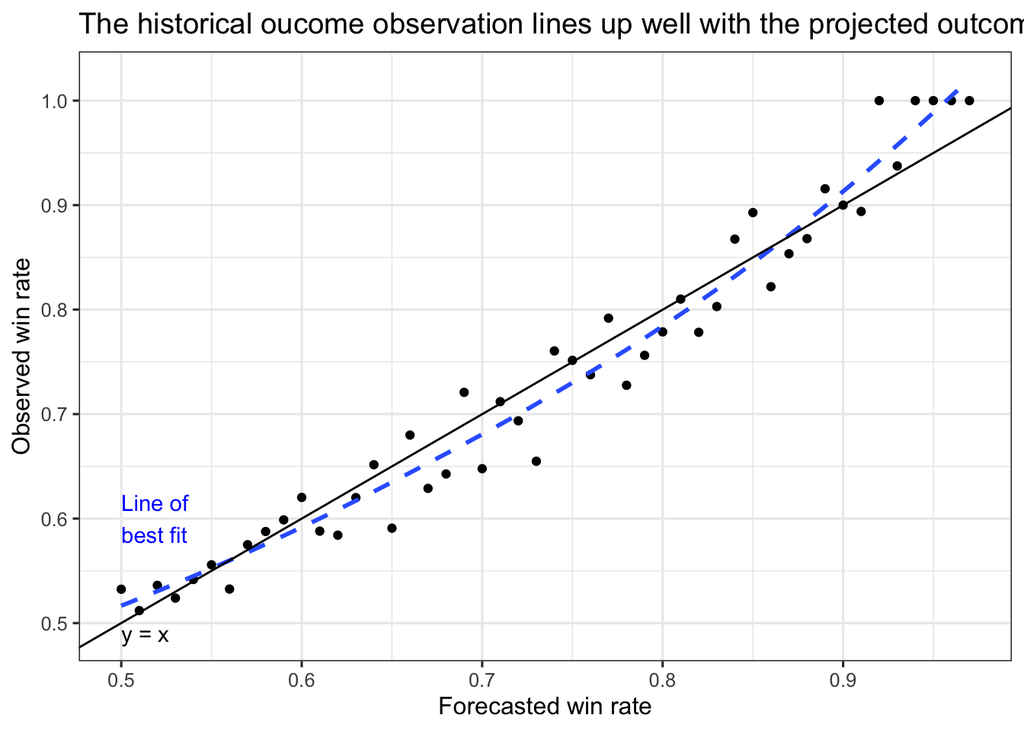

```r
read.csv("https://projects.fivethirtyeight.com/nfl-api/nfl_elo.csv") %>%
  mutate(loser_score = ifelse(qbelo_prob1 > qbelo_prob2, score2, score1),
         winner_score = ifelse(qbelo_prob1 > qbelo_prob2, score1, score2),
         p_win_winner = ifelse(qbelo_prob1 > qbelo_prob2, qbelo_prob1, qbelo_prob2),
         win = as.numeric(winner_score > loser_score),
         win_bucket = round(p_win_winner, 2)) %>%
  filter(!is.na(winner_score)) %>%
  group_by(win_bucket) %>%
  summarise(p = mean(win)) %>%
  ggplot(aes(x = win_bucket, y = p)) +
  geom_point() +
  geom_smooth(alpha = 0.7, linetype = "dashed", se = F, method = "loess", formula = "y ~ x") +
  geom_abline(slope = 1) +
  annotate("text", x = 0.5, y = 0.49, label = "y = x", hjust = 0) +
  annotate("text", x = 0.5, y = 0.6, label = "Line of \nbest fit", hjust = 0, color = "blue") +
  labs(title = "The historical oucome observation lines up well with the projected outcomes",
       x = "Forecasted win rate",
       y = "Observed win rate") +
  theme_bw(12)
```

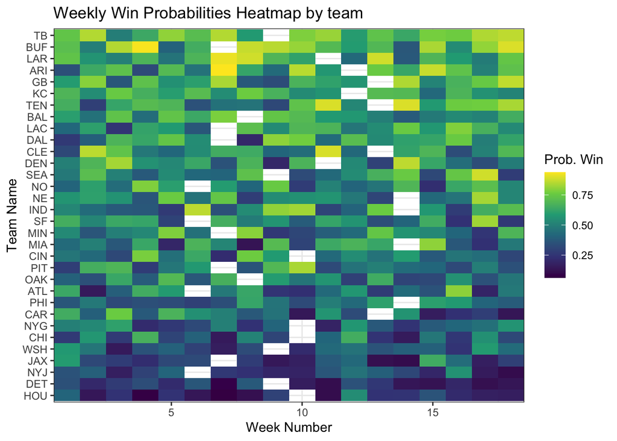

```r
fivethirtyeight = "https://projects.fivethirtyeight.com/nfl-api/nfl_elo_latest.csv"
plot_data = read_data(fivethirtyeight, all_weeks = TRUE)

plot_data %>%
  tidyr::pivot_longer(cols = c("loser", "winner"), values_to = "team") %>%
  mutate(p = ifelse(name == "loser", p_win, p_win_winner)) %>%
  select(-c("p_win", "p_win_winner")) %>%
  group_by(team) %>%
  mutate(win_avg = mean(p)) %>%
  ungroup() %>%
  mutate(team = reorder(team, win_avg)) %>% # reorder teams by avg win
  ggplot(aes(week, team, fill=p)) +
  geom_tile() +
  scale_fill_viridis_c("Prob. Win") +
  theme_bw() +
  labs(title = "Weekly Win Probabilities Heatmap by team",
       x = "Week Number",
       y = "Team Name") +
  scale_x_continuous(expand = c(0, 0))
```

### Determining the optimal pick profile

My approach for the contest was to pick teams based on their opportunity cost of not being selected, or in other words, the percentage differential towards the next best team to pick in a given week. Additionally, since lasting week to week is the most important aspect of the losers pool, I discount the opportunity cost so that future weeks are less important than upcoming weeks.

I also compare the results from my opportunity cost algorithm against a naive algorithm that picks the lowest probability team to win each week.

Another caveat of the contest is entrants are allowed to re-enter up until week 3. Due to the scarcity of teams in the pool, I run the model beginning at Week 3, and then pick from the remainder of teams in Weeks 1 and 2.

Last year, the pool lasted only until Week 10. For this reason, I also do not optimize my picks beyond this week. The pool is less about lasting to Week 18 as it is about outlasting the other competitors.

```r
# Picking functions ----
join_picks <- function(past_weeks, past_picks){
  picks <- setDT(data.frame(week = past_weeks, loser = past_picks))
  picks <- merge(picks, dt, on = week)
  picks <- picks[, .(week, loser, p_win)]

  return(picks)
}

by_oc <- function(dt, past_picks, past_weeks, start_week = 3, total_weeks = 10, beta = 1){

  for(i in start_week:total_weeks){

    pick <- dt[week %in% c(start_week:total_weeks)]
    pick <- pick[!week %in% past_weeks & !loser %in% past_picks, ]
    pick <- pick[order(week, p_win)]
    pick[, oc:= shift(p_win, 1, type="lead") - p_win, by = week]
    pick[, oc:= oc * beta^(week - start_week)]
    pick <- pick[, .SD[1], week]
    pick <- pick[order(-oc)]
    pick <- pick[, .SD[1]]

    past_weeks <- append(past_weeks, pick$week)
    past_picks <- append(past_picks, pick$loser)

  }

  picks <- join_picks(past_weeks, past_picks)

  return(picks)
}

by_week <- function(dt, past_picks, past_weeks, start_week = 3, total_weeks = 10, beta = 1){
  # loop through filling in each week
  for(i in start_week:total_weeks){
    pick <- dt[!loser %in% past_picks & week == i]
    pick[, value:= p_win * beta^(week - start_week)]
    pick <- pick[order(week, value)]
    pick <- pick[, .SD[1]]

    past_weeks <- append(past_weeks, pick$week)
    past_picks <- append(past_picks, pick$loser)

  }

  picks <- join_picks(past_weeks, past_picks)

  return(picks)
}

cumprob <- function(picks, inc_weeks = FALSE){
  p <- purrr::accumulate((1-picks$p_win), function(x, y)  x * y)
  weeks <- picks$Week
  if(inc_weeks){ out <- data.frame(p, weeks) }
  else { out <- data.frame(p) }

  out
}
```

Optimal Picks per Week

| Week | Oppertunity Cost Team | Oppertunity Cost ProbWin | Lowest Per Week Team | Lowest Per Week ProbWin | Diff |
| --- | --- | --- | --- | --- | --- |
| 1 | DAL | 0.264 | DAL | 0.264 | 0 |
| 2 | TEN | 0.286 | TEN | 0.286 | 0 |
| 3 | WSH | 0.153 | WSH | 0.153 | 0 |
| 4 | NYG | 0.214 | HOU | 0.068 | 0.146 |
| 5 | IND | 0.265 | MIA | 0.194 | 0.071 |
| 6 | HOU | 0.141 | PHI | 0.290 | -0.15 |
| 7 | DET | 0.083 | DET | 0.083 | 0 |
| 8 | MIA | 0.129 | NYJ | 0.235 | -0.106 |
| 9 | JAX | 0.145 | JAX | 0.145 | 0 |
| 10 | CAR | 0.144 | CAR | 0.144 | 0 |
| Mean |  | 0.182 |  | 0.186 |  |
| SD |  | 0.070 |  | 0.081 |  |

Given the Boolean nature of our predictions, we can compute the likelihood of reaching a given week based on our pick paths. Unsurprisingly, we see that the best pick per week model outperforms our opportunity cost model early on.

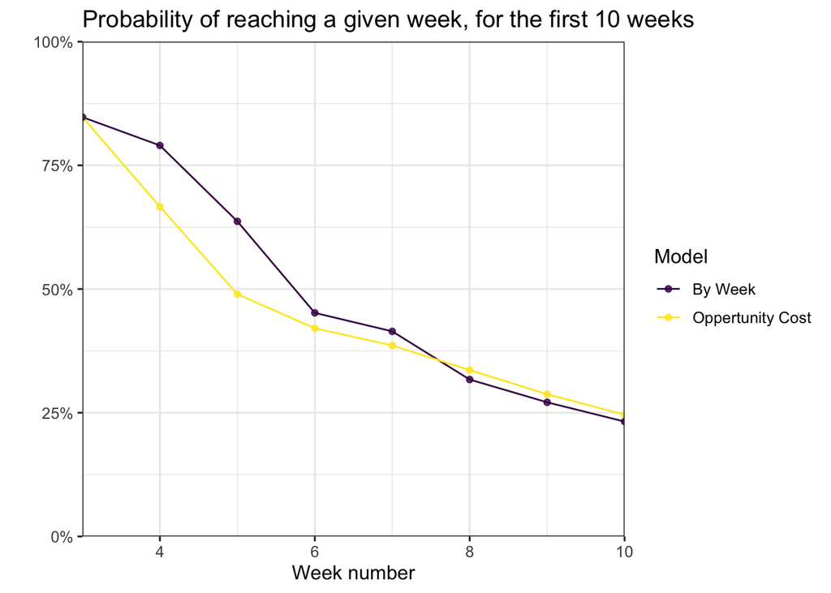

Visualizing the choice set of each model below, we can see the opportunity cost model takes on much greater risk in Weeks 4 and 5, to receive an edge in Weeks 6 and 8.

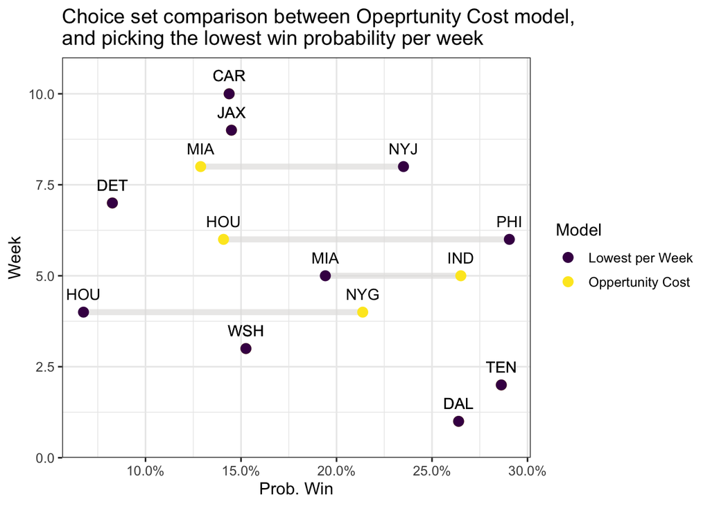

```r
# Plot choice set of each model ----
pick$approach = "Oppertunity Cost"
naive$approach = "Lowest per Week"
compare = rbind(pick, naive)

ggplot(compare, aes(x = week, y = p_win, color = approach, label = loser)) +
  geom_line(aes(group = week), color="#e3e2e1", size = 2, alpha = 0.7) +
  geom_point(size = 3) +
  geom_text(color = "black", nudge_x = 0.5) +
  scale_color_viridis_d() +
  coord_flip() +
  scale_x_continuous(expand = c(0, 0), limits = c(0, 11)) +
  scale_y_continuous(labels = percent) +
  labs(title = "Choice set comparison between Opeprtunity Cost model, \nand picking the lowest win probability per week",
       x = "Week",
       y = "Prob. Win",
       color = "Model") +
  theme_bw(12)
```

### Season Results

The season started with 33 players, with the season results shown below.

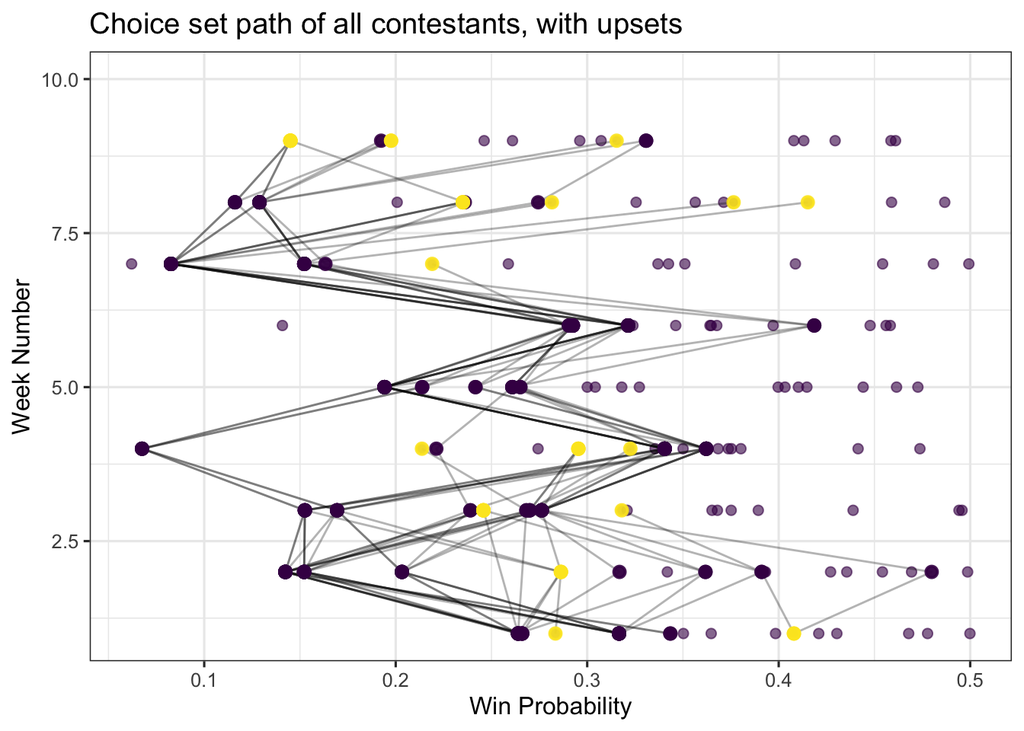

The season only lasted to Week 9, with three players splitting the pot.

Admittedly, I did not follow the above Oppertuniy Cost Algorithm perfectly. I had two entries, and so chose to offset the picks I was making each week to mitigate some of the risk.

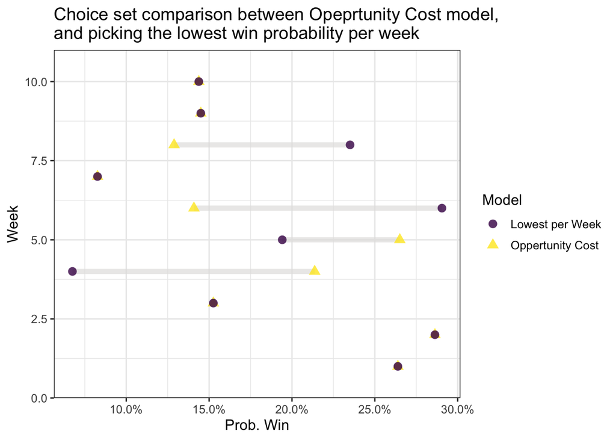

```r
# Plot actual selection ----
jordan_picks = own[grepl("Hutch", own$Player), c("Week", "Pick", "p_win", "Player")]
names(jordan_picks) = names(compare)

ggplot(compare, aes(x = week, y = p_win, color = approach, shape = approach, label = loser)) +
  geom_line(aes(group = week), color="#e3e2e1", size = 2, alpha = 0.7) +
  geom_point(size = 3, alpha = 0.8) +
  # geom_text(color = "black", nudge_x = 0.5) +
  scale_color_viridis_d() +
  coord_flip() +
  scale_x_continuous(expand = c(0, 0), limits = c(0, 11)) +
  scale_y_continuous(labels = percent) +
  labs(title = "Choice set comparison between Opeprtunity Cost model, \nand picking the lowest win probability per week",
       x = "Week",
       y = "Prob. Win",
       color = "Model",
       shape = "Model") +
  theme_bw(12)
```

If we compare the cumulative probabilities across the above models, and the actual picks I put into practice, we can see that the oppertunity cost model ended up with the higher probability by Week 10. The only downside is taking on the increased risk earlier in weeks 4 and 5.

```r
# Plot cumprob ----

# project remaining picks for each set of picks
jordan_1 = jordan_picks[jordan_picks$approach == "Hutch 1", ]
jordan_2 = jordan_picks[jordan_picks$approach == "Hutch 2", ]
jordan_1 = by_oc(dt, past_picks = jordan_1$loser[1:8], past_weeks = 1:8, beta = 1, start_week = 1, total_weeks = 10)
jordan_2 = by_oc(dt, past_picks = jordan_2$loser[1:7], past_weeks = 1:7, beta = 1, start_week = 1, total_weeks = 10)

# add to dataset
jordan_1$approach = "Jordan 1"
jordan_2$approach = "Jordan 2"
models = list(pick[3:10, ], naive[3:10, ], jordan_1[3:10, ], jordan_2[3:10, ])
models = lapply(models, cumprob) %>%
  bind_cols()
```

```
## * p -> p...1
## * p -> p...2
## * p -> p...3
## * p -> p...4
```

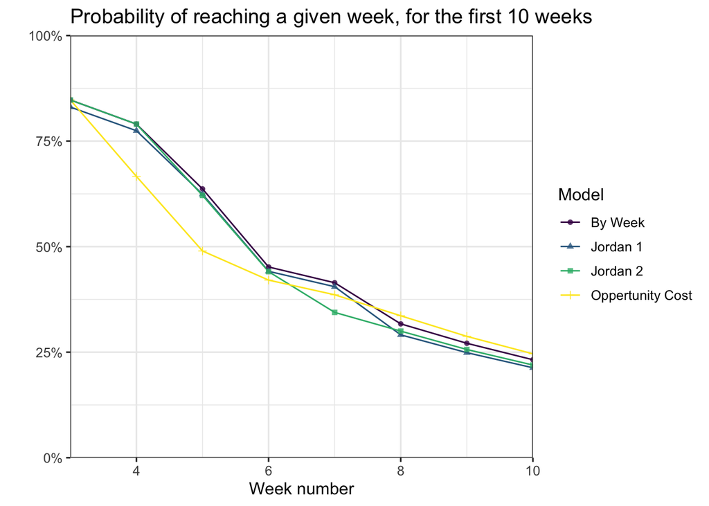

```r
models$week = 3:10
names(models) = c("Oppertunity Cost", "By Week", "Jordan 1", "Jordan 2", "Week")
models %>%
  tidyr::pivot_longer(cols = -Week, names_to = "Model", values_to = "p") %>%
  ggplot(aes(x = Week, y = p, color = Model, shape = Model)) +
  geom_line() +
  geom_point(alpha = 0.8) +
  scale_x_continuous(expand = c(0, 0), limits = c(3, 10)) +
  scale_y_continuous(expand = c(0, 0), limits = c(0, 1), labels = percent) +
  scale_color_viridis_d() +
  labs(title = "Probability of reaching a given week, for the first 10 weeks",
       x = "Week number",
       y = "") +
  theme_bw(12)
```

Using the same chart format, what do things look like for all the competitors in the pool? We don’t know the picks that would be made by compeditors who’ve lost in earlier weeks, therefore, I will only plot the projected probabilities up until each person lost.

In order to compare my performance with others, I plotted my pick projections in purple. We can see, I was in great shape before losing my second team in Week 7 and top team in Week 8. In fact, My probability of making week 8 was greater than that of a majority of teams making week 6.

Despite not making the final 3 in the pool - the payout positions - my algorithm placed me in a fantastic position to make money in the pool.

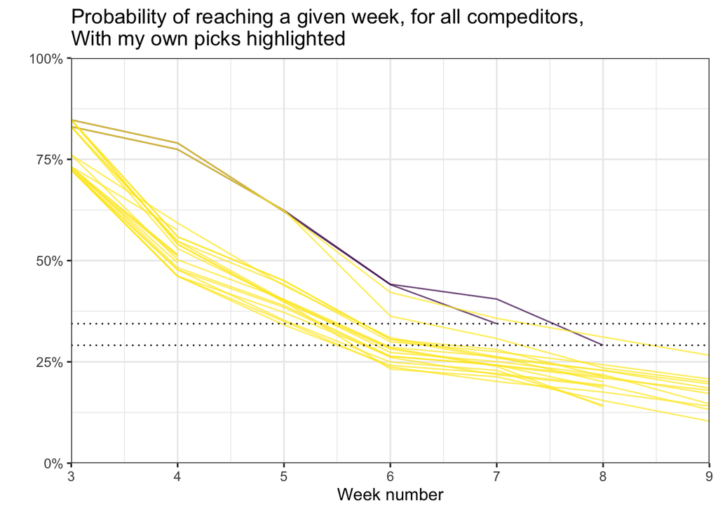

```r
# plot cumulative probabilities
tbl_data = filter(own, Pick != "OUT" & Week > 2) %>%
  group_by(Player) %>%
  mutate(cum_prob = cumprod(1-p_win),
         own = ifelse(Player == "Hutch 1" | Player == "Hutch 2", TRUE, FALSE)) %>%
  ungroup() %>%
  group_by(Player) %>%
  mutate(win_avg = max(Week) + (min(cum_prob))) %>%
  ungroup() %>%
  mutate(Player = reorder(Player, win_avg))

ggplot(tbl_data, aes(x = Week, y = cum_prob, group = Player, color = own)) +
  geom_line(alpha = 0.7) +
  scale_x_continuous(expand = c(0, 0), limits = c(3, 9)) +
  scale_y_continuous(expand = c(0, 0), limits = c(0, 1), labels = percent) +
  scale_color_viridis_d(direction = -1) +
  geom_hline(yintercept = min(subset(tbl_data, Player == "Hutch 1")$cum_prob), linetype = "dotted") +
  geom_hline(yintercept = min(subset(tbl_data, Player == "Hutch 2")$cum_prob), linetype = "dotted") +
  labs(title = "Probability of reaching a given week, for all compeditors, \nWith my own picks highlighted",
       x = "Week number",
       y = "") +
    theme_bw(12) +
    theme(legend.position = "none")
```

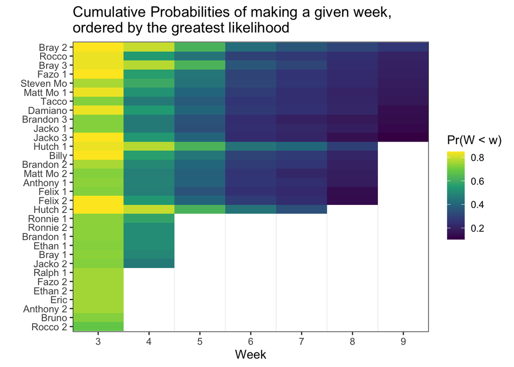

```r
# plot heatmap of cum prob
ggplot(tbl_data, aes(y = Player, x = Week, fill = cum_prob)) +
  geom_tile() +
  scale_x_continuous(expand = c(0, 0), breaks = 3:9) +
  scale_fill_viridis_c(direction = 1) +
  labs(title = "Cumulative Probabilities of making a given week, \nordered by the greatest likelihood",
       x = "Week",
       y = "",
       fill = "Pr(W < w)") +
  theme_bw(12) +
  theme(panel.grid.major = element_blank())
```